# Chapter17 回帰不連続デザインの仮定および実践

# はじめに

- 回帰不連続デザインについて具体的にみてきた
- 回帰不連続デザインの基本的なアイデア
  - 処置群における閾値上の値と統制群における閾値上の値を比較することで
  - 局所的な平均処置効果を推定
- 強制変数$X$ は、連続変数
  - 閾値上の真上に、観測値は存在しない（テキストまま）
  - (意見) 観測値データを見ずに、任意に選んだ閾値上にたまたま値があることはないだろう、ということ
    - 理論的には、無限の連続データを観測値にすることができれば、その限りではないが、その議論はしてもよいが非現実的
  - この推定方法が正当化されるには、連続性の仮定が満たされる必要がある
    - (意見) 確かに、推定したい点に対する値が存在しない関数形(データ不存在・取得不可)なら、推定どころではない
- 本章
  - 前半：回帰不連続デザインに必要な仮定について議論
  - 後半：実践的なデータ解析を行う
    - ここまで扱ってきた回帰不連続デザインに関する知識と技術を総動員！

本章で使うデータを読み込んでおきます

```r
library(tibble)
library(knitr)
library(kableExtra)
library(DiagrammeR)
```

```r
rm(list=ls())

load_data <- function(url.data.file){
  D <- read.csv(url(url.data.file))
  return(D)
}

Da <- load_data("https://raw.githubusercontent.com/mtakahashi123/causality/main/data17a.csv")
Db <- load_data("https://raw.githubusercontent.com/mtakahashi123/causality/main/data17b.csv")
```

# 17.1 連続性の仮定と強制変数の操作

- 条件付き回帰関数の連続性 (continuity of conditional regression functions)
  - 回帰不連続デザインの識別性の条件が与えられた (Hahn et al.(2001), 15.8 節 で触れた)
  - c を閾値とすると $E[Y(0) | X=x]$ と $E[Y(1) | X=x]$ は、$x=c$ の付近において連続という条件
  - 便宜的に、本書では、「連続性の仮定」と略称することにする
    - (Imbens and Lemieux, 2008, p.618; 西山・新谷・川口・奥井, 2019, p.444)
  - 潜在的結果変数 $\{ Y(0), Y(1) \}$ の条件付き分布に、連続性があるという意味
- この仮定が満たされないとき
  - **閾値における局所的な平均処置効果(LATE) は推定できない**
- 潜在的結果変数 $\{ Y(0), Y(1) \}$ の条件付き分布に連続性がないとは？！
  - 典型例
    - 閾値の存在が知られていて、強制変数$X$ の値が操作できる場合である
  - e.g. 平均70点、標準偏差10点の試験
    - 以下の情報はオープンで
      - 90点以上：学費免除
      - 90点未満：学費免除なし
    - 強制変数の操作が行われる時
      - 一部の受験生が試験問題を事前に入手している場合
        - 意図的に90点以上を取れるだろう
      - 一部の受験生の試験結果に対して採点者が不正に加点している場合
        - こちらも、意図的に90点以上を取れるだろう
  - (感想)
    - 操作されているとなぜ「連続性の仮定」が満たされないのか
    - 特定の値(頻度や密度)以上が、非常に値が伸びる、ということだろうか？だとしたら、連続性というか微分可能性のような
      - 本来とるべき値が欠測することで、連続性が担保されないということだろうか
        - 全数にもよるが、たかだか、数人が不正をしたからといって、連続性が崩れるとは思えないなー
      - 一方で、連続性が担保されない状況なら、微分可能性も担保されなくなるので、より強い条件を制約としているとも言える
      - グラフ的には、途切れて見れるだろうということかもしれない
  - 強制変数の操作が行われている場合
    - 回帰不連続デザインによる因果推論は、妥当とは認められない

## 17.1.1 強制変数の操作の仮定の緩和条件

- 強制変数の操作の仮定は緩和できると知られている (Lee, 2008, p.677)
- 強制変数の操作の仮定
  - 閾値がどこにあるかが単に知られているだけでなく、強制変数の値が正確に操作されるという意味
  - というのも、何も勉強せずに試験を受けに行く人はほとんどいない
  - 学生は、実際に強制変数に対して何らかの操作を行っている、といえよう
- 例
  - ある学生が、90点以上で授業料が免除になることを知らないとする
    - この学生が、試験勉強をせずに受験した場合で、試験の点数が50点
  - 通常は、勉強してから受験するので実際の点数は80点だった
  - この学生が、授業料免除を知っているなら、90点以上の点数を取りたいと思うはず
  - ただ、実際には、すでに十分勉強をして準備をした上での点数が80点なのであれば、
    - 閾値が90点であることを知った上でも、90点以上の点数が取れるとは限らない
- McCrary (2008, p.700)
  - 部分的な操作 (partial manipulation)
  - 完全な操作 (complete manipulation)
    - 問題となるのは、こっちのみと指摘
- 15.4節
  - 強制変数 $X_i$ は、ベースラインとなる変数 $W_i$ と無作為なノイズ $V_i$ の線形和と考える
- Lee (2008, pp.679-681)
  - 強制変数の操作が行われていても、局所的な無作為割付けは成立していることを示した
  - ただし、閾値を超える操作を正確に行うことができなければ
    - (意見) チートが成立しなければ
- 現実の社会問題を考える上で、強制変数の操作の仮定が問題にならないだろうか？！
  - 例 : 夫婦共働き世帯
    - 一人：フルタイムで働く
    - もう一人：パートタイムで働く
      - 所得控除を考えて、パートから得られる年間収入が103万円以下に抑えられる傾向があると知られている
    - 指摘 (森田, 2014, p.254)
      - 103万円のちょうど上と下の分布を比べると
        - 103万円よりわずかに少ない年収の人が
        - 103万円以上の年収の人よりも多くなっているはず、と指摘されている
    - これも、可能性の問題(テキストまま)
      - 1月の段階で、年収が102万円になるように出勤回数を計画することは可能
      - 11月の段階で、年収が102万円に達していたとして
        - 12月は一切出勤しないという選択ができるだろうか？！
      - このように、正確な操作(理想的な操作？)ができないなら
        - 実際に103万円のちょうど上と下の分布を比べた場合、103万円の上と下の分布には顕著な差がないだろう
    - 閾値の前後で、顕著な差が**ある**のであれば、**強制変数の操作の仮定が満たされていない** おそれ
      - (意見) i.e. 強制変数が完全に操作されないという仮定が満たされない。完全に操作しうる状況が疑われるということ
      - (混乱注意) これは、強制変数$X$ の話。結果変数$Y$ の話ではないので、安心してください！（笑）

## 17.1.2 グラフによる連続性の仮定の診断

- Lee and Lemiux, 2015, pp.316-317
  - 強制変数の分布を確認することで、この仮定の妥当性が検証できる（と示唆）
  - 具体的には、ヒストグラムで可視化できる
- 実際に見てみる
  - x1: 強制変数。操作が行われていない
  - x2: 強制変数。操作が行われている
  - ヒストグラムと検定で、操作有無を発見できるか？！
  - 閾値：60

```r
attach(Da)
summary(Da)
```

```
##        x1              x2
##  Min.   :15.00   Min.   :15.00
##  1st Qu.:43.00   1st Qu.:43.00
##  Median :50.00   Median :50.00
##  Mean   :49.96   Mean   :50.84
##  3rd Qu.:57.00   3rd Qu.:60.00
##  Max.   :86.00   Max.   :86.00
```

**図17.1**

以下、図17.1 (x1 の分布) では、閾値60 の前後には特異な状況は発見されていない。ごく普通の正規分布に見える。

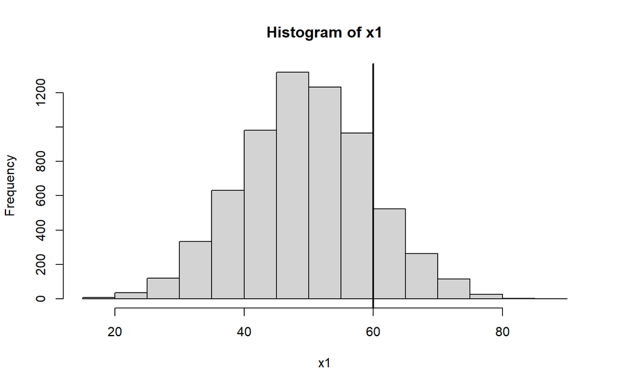

```r
hist(x1)
abline(v=60, lwd=2)
```

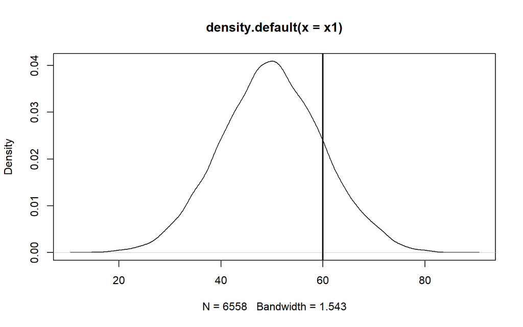

```r
plot(density(x1))
abline(v=60, lwd=2)
```

**図17.2**

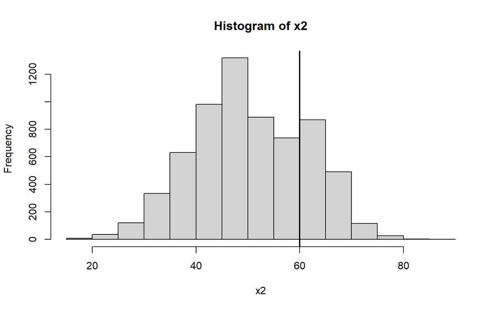

```r
hist(x2)
abline(v=60, lwd=2)
```

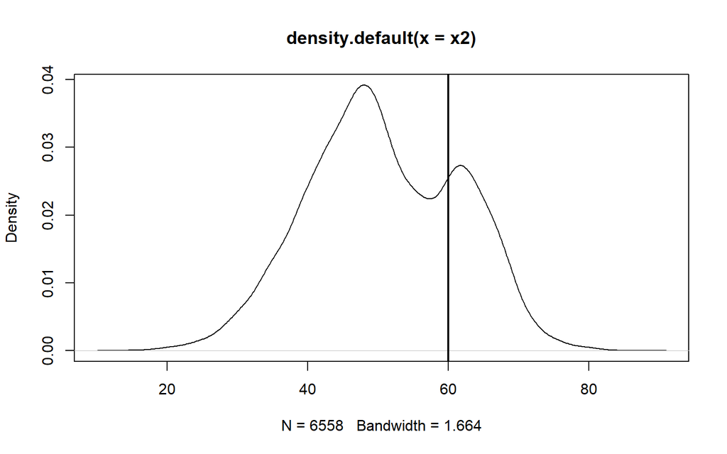

```r
plot(density(x2))
abline(v=60, lwd=2)
```

## 17.1.3 フォーマルな検定による連続性の仮定の診断

- フォーマルな検定
  - McCrary (2008) の手法
    - 有名
  - Cattaneo, Jansson, and Ma (2018, 2020) の手法
    - McCrary の検定における標本サイズは小さくなりすぎると指摘
      - i.e. 検出力に問題がありうると指摘
    - 局所的多項式密度推定量 (local polynomial density estimator)に基づく、新たな検定を提案
    - 事前に、データをビン(ヒストグラムのバー) に分割する必要がない
    - 矩形関数、三角形関数などの単純なカーネルを利用できるため、実際的
- データ全体が処置群と統制群にわけられているケースを考える
  - 処置群：$x_i < c$ の部分のデータ
  - 統制群：$x_i \ge c$ の部分のデータ
  - この２種類のデータを用いて、確率密度関数$f(x)$ が c において連続かどうかを検定する
  - 帰無仮説 $H_0$、対立仮説 $H_1$ は、下式(17.1) の通り

  $$\begin{align}
  H_0: \lim_{x \uparrow c} f(x) = \lim_{x \downarrow c} f(x) \\
  H_1: \lim_{x \uparrow c} f(x) \ne \lim_{x \downarrow c} f(x) \\
  \tag{17.1}
  \end{align}$$
  - 帰無仮説 $H_0$ は、$x$ を $c$ に左から近づけた左極限における $f(x)$ が、
    - $x$ を $c$ に右から近づけた右極限における $f(x)$ と一致することを意味している
    - (感想) これは、連続の定義をそのまま翻訳した形 / 脚注にも書いてあった
    - つまり、
      - 左辺は、$c$ において左側連続、右辺は $c$ において右側連続を意味している
  - 対立仮説 $H_1$ は、この2つが一致していないことを意味している
  - 要しよう
    - 有意水準 $\alpha$ において、帰無仮説を棄却できる場合、連続でないという結論になる
      - i.e. 回帰不連続デザインを使う仮定が満たされない
    - 回帰不連続デザインを使用するためには、**帰無仮説が棄却されない方が望ましい**
    - (脚注) 帰無仮説を棄却できない場合、帰無仮説が正しいことが示されたわけではない
      - しかし、帰無仮説が間違っているという証拠もない
      - なので、「回帰不連続デザインの適用に問題はない」と便宜上みなす、ということ
- 理論/数式も理解したいひと向け
  - 検定統計量 $T_p(h)$ は、下式(17.2) の通り定義されている
  - Cattaneo, Jansson, and Ma, 2020, p.1450
    - $p$ : 多項式の次数
    - $h$ : バンド幅
    - $n$ : 標本サイズ
    - $\hat{V}(x)$ : 分散の推定値
    - $\hat{f}(x)$ : 局所多項式回帰の回帰係数として推定された確率密度関数
    - 添字$_{+}$ : $x_i \ge c$ の部分のデータ
    - 添字$_{-}$ : $x_i \lt c$ の部分のデータ
    - $T_p(h)$ の分布は、標準正規分布で近似できる (Cattaneo, Jansson, and Ma, 2020, p.1453)

  $$T_p(h) := \frac{\frac{n_{+}}{n} \hat{f}_{+}(c) - \frac{n_{-}}{n}
  \hat{f}_{-}(c) }{\sqrt{ \frac{n_{+}}{n^2 h_{+}} \hat{V}_{+}(c) +
  \frac{n_{-}}{n^2 h_{-}} \hat{V}_{-}(c) }} \\
  \tag{17.2}$$

**強制変数の操作の検定**

```r
library(rddensity)
summary(rddensity(x1, c=60))
```

```
##
## Manipulation testing using local polynomial density estimation.
##
## Number of obs =       6558
## Model =               unrestricted
## Kernel =              triangular
## BW method =           estimated
## VCE method =          jackknife
##
## c = 60                Left of c           Right of c
## Number of obs         5445                1113
## Eff. Number of obs    5131                1113
## Order est. (p)        2                   2
## Order bias (q)        3                   3
## BW est. (h)           26                  26
##
## Method                T                   P > |T|
## Robust                0.7754              0.4381
```

```
##
## P-values of binomial tests (H0: p=0.5).
##
## Window Length / 2          <c     >=c    P>|T|
## 0.000                       0     182    0.0000
```

```r
summary(rddensity(x2, c=60))
```

```
##
## Manipulation testing using local polynomial density estimation.
##
## Number of obs =       6558
## Model =               unrestricted
## Kernel =              triangular
## BW method =           estimated
## VCE method =          jackknife
##
## c = 60                Left of c           Right of c
## Number of obs         4871                1687
## Eff. Number of obs    4557                1687
## Order est. (p)        2                   2
## Order bias (q)        3                   3
## BW est. (h)           26                  26
##
## Method                T                   P > |T|
## Robust                13.0866             0
```

```
##
## P-values of binomial tests (H0: p=0.5).
##
## Window Length / 2          <c     >=c    P>|T|
## 0.000                       0     182    0.0000
```

- 変数x1
  - 検定統計量: 0.7754
  - p値: 0.4381
  - 5% の有意水準で帰無仮説は棄却されない
- 変数x2
  - 検定統計量: 13.0866
  - p値: 0
  - 5% の有意水準で帰無仮説は棄却される
- 先ほど(17.1.2項)、グラフで判断したものと一致
  - 強制変数x1 : 操作なし
  - 強制変数x2 : 操作あり

### 結論

- グラフと検定で、強制変数への操作有無が判定できるとわかった

# 17.2 Rパッケージrdrobust による分析：上級編

- いよいよ、本格的な回帰不連続デザインによる分析！
- 「ヘッドスタート（Head Start）は子供たちの生存の可能性を改善するか」という論文で解析されたデータを利用
  - Ludwig and Miller (2007)
- ヘッドスタート
  - 1965年以来、貧困との戦い(War on Poverty) の一環として
  - 低所得層の児童を対象とする米国政府の政策
  - Ludwig and Miller (2007, p.159)

```r
detach(Da)
```

## 17.2.1 使用するデータ

- 使用するデータ (Ludwig and Miller, 2007, pp.169-170)
  - 一部が欠測しているデータ
  - y1 : 結果変数
    - 5歳〜9歳までの致死率
      - 正確には、人口10万人当たりの死亡数
      - 100を超えている観測数もある
  - x1 : 強制変数
    - 貧困率
  - z1 〜 z9 : 共変量
    - 1: 郡の全人口数
    - 2: 14歳〜17歳の割合
    - 3: 3歳〜5歳の割合
    - 4: 25歳以上の割合
    - 5: 14歳〜17歳の人数
    - 6: 3歳〜5歳の人数
    - 7: 25歳以上の人数
    - 8: 都市部人口の割合
    - 9: 黒人人口の割合
  - c1 : 閾値59.1984
    - 処置は、応募書類作成のための技術的な援助
      - 貧困率が下位300番目の郡まで与えられた
    - 貧困率が下位300番目の貧困率(x1の値)が、59.1984 (欠測値を除く前のデータでの300番目)
- ヘッドスタート
  - 1965年から開始された
  - その直前の国勢調査は、1960年
  - 使用されたデータは、1960年当時のもの
  - 観測単位は、郡(country)
  - 観測数は、2,809 / 欠測値を除くと観測数は、2,779

```r
df3 <- na.omit(Db)      # 欠測値を除外
attach(df3)
summary(df3)
```

```
##        y1                x1              z1                z2
##  Min.   :  0.000   Min.   :15.21   Min.   :    376   Min.   :  0.00
##  1st Qu.:  0.000   1st Qu.:24.14   1st Qu.:   9237   1st Qu.: 82.40
##  Median :  0.000   Median :33.64   Median :  17235   Median : 87.30
##  Mean   :  2.257   Mean   :36.75   Mean   :  39254   Mean   : 84.09
##  3rd Qu.:  2.830   3rd Qu.:47.24   3rd Qu.:  33701   3rd Qu.: 91.60
##  Max.   :136.054   Max.   :81.57   Max.   :2664438   Max.   :100.00
##        z3               z4              z5                 z6
##  Min.   :0.1963   Min.   : 6.50   Min.   :    22.0   Min.   :    165
##  1st Qu.:0.5162   1st Qu.:24.70   1st Qu.:   685.5   1st Qu.:   4010
##  Median :0.5524   Median :33.50   Median :  1267.0   Median :   7874
##  Mean   :0.5514   Mean   :33.18   Mean   :  2571.3   Mean   :  18311
##  3rd Qu.:0.5892   3rd Qu.:41.00   3rd Qu.:  2372.5   3rd Qu.:  15521
##  Max.   :0.7516   Max.   :70.50   Max.   :153908.0   Max.   :1180784
##        z7                z8               z9
##  Min.   :    214   Min.   :  0.00   Min.   : 0.00
##  1st Qu.:   5080   1st Qu.:  0.00   1st Qu.: 0.10
##  Median :   9249   Median : 28.30   Median : 1.50
##  Mean   :  21731   Mean   : 29.09   Mean   :10.61
##  3rd Qu.:  17715   3rd Qu.: 47.80   3rd Qu.:14.90
##  Max.   :1611158   Max.   :100.00   Max.   :83.40
```

```r
c1 <- 59.1984
```

```r
nrow(Db)
```

```
## [1] 2809
```

```r
nrow(df3)
```

```
## [1] 2779
```

```r
sort(Db$x1, decreasing=TRUE)[300]       # c1 の値
```

```
## [1] 59.19841
```

## 17.2.2 データの可視化

- 散布図とRDプロットを描いて可視化
  - データの全体像
  - 分布形
  - 不連続点

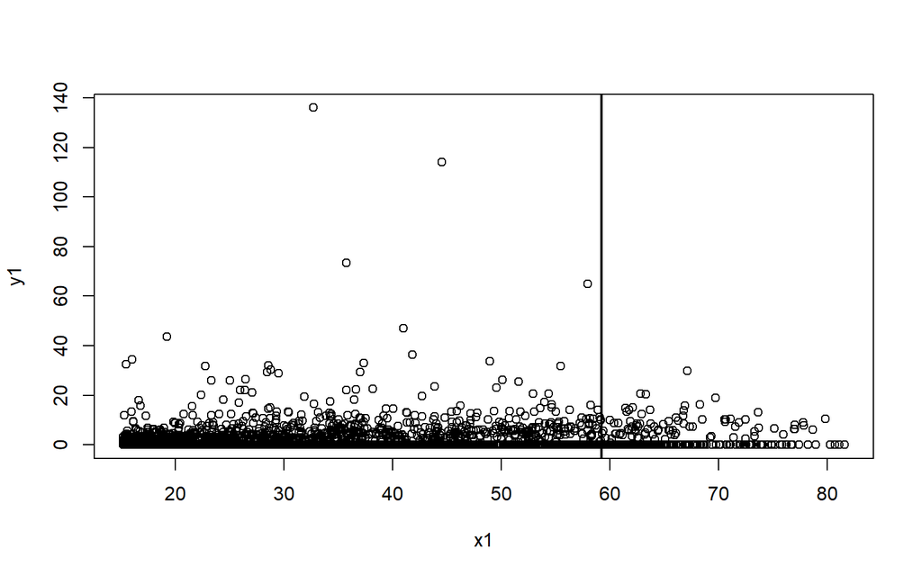

```r
plot(x1, y1)
abline(v=c1, lwd=2)
```

- ↑の散布図では、縦軸側に外れ値があるため、全体像がわかりにくい
- y1 の 95%点は、10.0152
  - ほとんどの値が、10以下であろうとわかる

```r
quantile(y1, 0.95)    # 95%点
```

```
##     95%
## 10.0152
```

```r
quantile(y1, 0.94)    # 94%点
```

```
##      94%
## 8.982242
```

- ということで、y1の軸(縦軸)を10を最大にして散布図を描いてみる

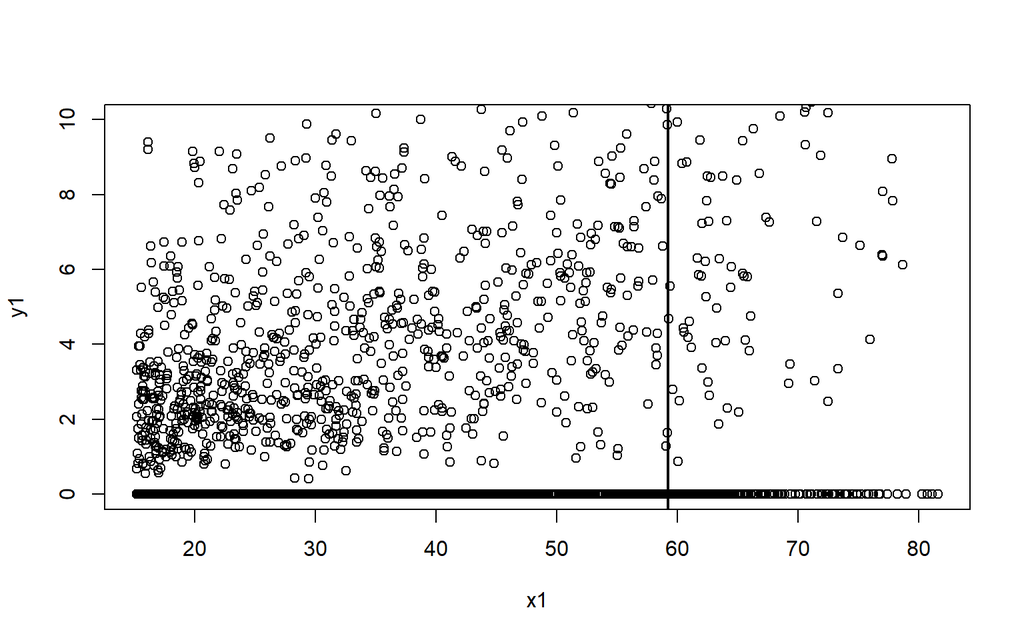

```r
plot(x1, y1, ylim=c(0, 10))
abline(v=c1, lwd=2)
```

- 縦軸のスケールを小さくしても、結局ばらつきが大きすぎて、よくわからない
- そこで、16.8節で導入した、RD プロットを活用する
  - データ内の潜在的な変動をうまく補足できるように
  - 横軸をビンに区切って、ビン内の平均値を計算することでスムーズ化している
  - (Calonico et al., 2015a, pp.44-45)

```r
c1
```

```
## [1] 59.1984
```

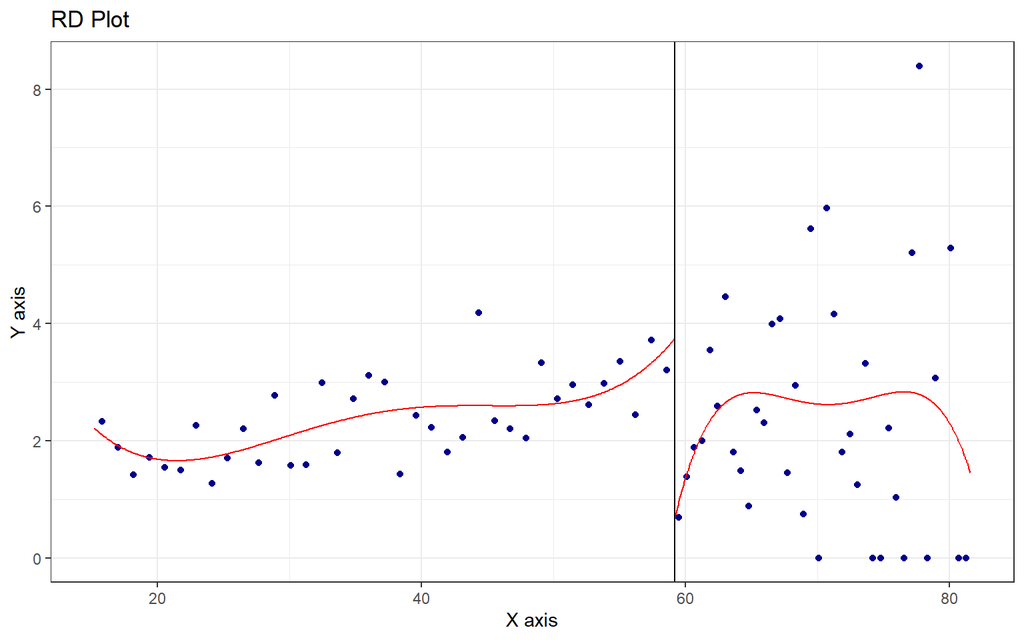

```r
library(rdrobust)

rdplot(y1, x1, c=c1)
```

- このようにスムーズ化したことにより、閾値 c=59.1984 付近で不連続
  - この部分の差が局所的な平均処置効果を表している様子が可視化されている
  - (感想) 閾値よりちょっと右のところは、データ数が少ないから、不連続と言い切ってよいかは疑問・・
    - と思ったが、平均値をとっているから、数点(ビン内)を要約している値なので、問題ないってことっぽい
- 散布図は、必ずしも必要ではない
  - 回帰不連続デザインでは、可視化に散布図を利用されないことが多い（らしい）
- しかし、RD プロットだけではなく、実際の散布図からもデータの分布を確認しておく方が、より有益（らしい）
  - なぜなら、RD プロットは、実際のデータを図示しているのではなく、平滑化したデータを図示しているため
  - これは、時系列データにおける、原データと季節調整済みデータ（移動平均をとったデータ）の違いのようなもの（らしい）
  - (感想) RD プロットは、ビン毎に平均した値がプロットされているから、ということっぽい
    - 時系列の話はその通りだと思う。ばらつきは、移動平均ではわからないだろうし

## 17.2.3 連続性の仮定の診断

- 次に、グラフと検定から、連続性の仮定に問題がありそうか確認する！

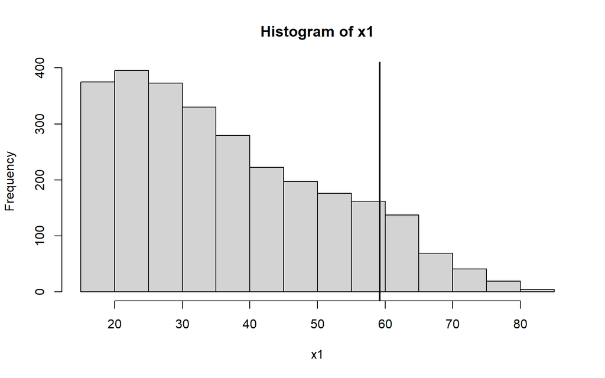

```r
hist(x1)
abline(v=c1, lwd=2)
```

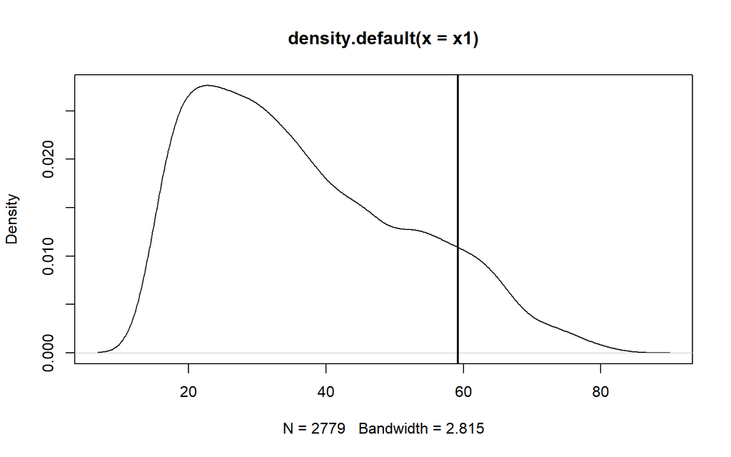

```r
plot(density(x1))
abline(v=c1, lwd=2)
```

```r
library(rddensity)
summary(rddensity(x1, c=c1))
```

```
##
## Manipulation testing using local polynomial density estimation.
##
## Number of obs =       2779
## Model =               unrestricted
## Kernel =              triangular
## BW method =           estimated
## VCE method =          jackknife
##
## c = 59.198            Left of c           Right of c
## Number of obs         2485                294
## Eff. Number of obs    332                 211
## Order est. (p)        2                   2
## Order bias (q)        3                   3
## BW est. (h)           9.593               8.468
##
## Method                T                   P > |T|
## Robust                -0.4671             0.6404
##
##
## P-values of binomial tests (H0: p=0.5).
##
## Window Length / 2          <c     >=c    P>|T|
## 0.304                      10      10    1.0000
## 0.608                      20      20    1.0000
## 0.912                      32      27    0.6029
## 1.216                      45      35    0.3143
## 1.520                      53      40    0.2132
## 1.825                      62      50    0.2986
## 2.129                      72      59    0.2944
## 2.433                      77      68    0.5066
## 2.737                      81      75    0.6891
## 3.041                      96      84    0.4124
```

- ヒストグラム、密度推定した結果の可視化
  - 特に多峰性がないので、連続っぽい
- 検定の結果
  - 帰無仮説（左側連続＝右側連続）を5%の有意水準で棄却できないため、連続っぽい(連続の可能性は否定できない)
- (解釈) 回帰不連続デザインに必要な、連続性の仮定が満たされると考えて、次に進むっぽい

## 17.2.4 解析１：共変量なし

- 実際にモデリングしていこう
  - ３種類のバンド幅でモデリング
    - IKバンド幅
    - CER最適化バンド幅
    - MSE最適化バンド幅
  - カーネルは、triangular(三角形関数) を決めうちで使用
    - 実証研究では、カーネル関数も試すとよい
  - 引数に、`all=TRUE` を指定すると
    - Bias-Corrected, Robust の項目にも出力結果が表示される

```r
IKband <- rdbwselect_2014(y1, x1, c=c1, bwselect="IK")
IKband
```

```
## Call:
## rdbwselect_2014(y = y1, x = x1, c = c1, bwselect = "IK")
##
## BW Selector   IK
## Number of Obs 2779
## NN Matches    3
## Kernel Type   Triangular
##
##                    Left Right
## Number of Obs      2485 294
## Order Loc Poly (p) 1    1
## Order Bias (q)     2    2
##
##             h        b
## [1,] 14.82155 18.89179
```

```r
IKband$bws[1, 1]
```

```
##        h
## 14.82155
```

```r
h <- IKband$bws[1, 1]
model.1 <- rdrobust(y1, x1, c=c1, h=h, all=TRUE)
model.2 <- rdrobust(y1, x1, c=c1, bwselect="cerrd", all=TRUE)
model.3 <- rdrobust(y1, x1, c=c1, bwselect="mserd", all=TRUE)
```

```r
summary(model.1)
```

```
## Sharp RD estimates using local polynomial regression.
##
## Number of Obs.                 2779
## BW type                      Manual
## Kernel                   Triangular
## VCE method                       NN
##
## Number of Obs.                 2485          294
## Eff. Number of Obs.             534          267
## Order est. (p)                    1            1
## Order bias  (q)                   2            2
## BW est. (h)                  14.822       14.822
## BW bias (b)                  14.822       14.822
## rho (h/b)                     1.000        1.000
## Unique Obs.                    2485          294
##
## =============================================================================
##         Method     Coef. Std. Err.         z     P>|z|      [ 95% C.I. ]
## =============================================================================
##   Conventional    -1.844     0.875    -2.106     0.035    [-3.559 , -0.128]
## Bias-Corrected    -2.403     0.875    -2.746     0.006    [-4.119 , -0.688]
##         Robust    -2.403     1.211    -1.985     0.047    [-4.777 , -0.030]
## =============================================================================
```

```r
sum(model.1$N)            # Number of Obs.
```

```
## [1] 2779
```

```r
model.1$bwselect          # BW type
```

```
## [1] "Manual"
```

```r
model.1$kernel            # Kernel
```

```
## [1] "Triangular"
```

```r
model.1$vce               # VCE method
```

```
## [1] "NN"
```

- `Number of Obs.` : 2779 個の観測データとわかる
- `BW type` : Manual なので、手作業とわかる
  - ここでは、IKバンドを手作業で指定したので、Manual になっている
- `Kernel` : デフォルトの Triangular (三角形関数)
- `VCE method` : 分散共分散の推定法、デフォルトの NN
  - NN : Nearest Neighbour
  - 不均一分散に強い、NN に基づく分散推定 (Calonico et al., 2021, p.14)

```r
model.1$N                 # 2nd Number of Obs.
```

```
## [1] 2485  294
```

```r
model.1$N_h               # Eff. Number of Obs.
```

```
## [1] 534 267
```

```r
model.1$p                 # Order est. (p)
```

```
## [1] 1
```

```r
model.1$q                 # Order bias (q)
```

```
## [1] 2
```

```r
model.1$bws               # BW est. (h) / BW bias (b)
```

```
##       left    right
## h 14.82155 14.82155
## b 14.82155 14.82155
```

```r
h <- model.1$bws[1, 1:2]
b <- model.1$bws[2, 1:2]
h / b                     # rho (h/b)
```

```
##  left right
##     1     1
```

```r
model.1$M                 # Unique Obs.
```

```
## [1] 2485  294
```

- `Number of Obs.` (2個目) : 2485, 294 の２つ
  - 2485 : 閾値よりも下の観測データ数
  - 294 : 閾値よりも上の観測データ数
- `Eff. Number of Obs.` : 534, 267 の２つ
  - 534 : 閾値より下のバンド幅の中の観測データ数
  - 267 : 閾値より上のバンド幅の中の観測データ数
- `Order est. (p)` : 局所回帰モデルの多項式の次数、ここでは次数は1
  - つまり、局所線形回帰モデル
  - 局所二次回帰モデルを使いたい場合は、rdrobust 関数の引数に、`p=2` と指定する
- `Order bias (q)` : バイアスを修正するための多項式の次数
  - デフォルトで、q=p+1
- `BW est. (h)` : IKバンド幅(Imbens and Kalyanaraman (2012) の方法で推定されたバンド幅)
  - h=IKband$bws[1, 1] と指定したことから
  - 14.822 が左右に２個表示。これは、閾値の左側のバンド幅と右側のバンド幅を意味する
- `BW bias (b)` : バイアス修正したバンド幅
  - 手作業でバンド幅を指定した場合には、`BW est. (h)` と同じになる
- `rho (h/b)` : バイアス修正したバンド幅
  - 通常のバンド幅とバイアス修正したバンド幅の比
  - 今回は、２つとも、同じ値なので、1.000 である
- `Unique Obs.` : 重複する値を除いた観測数
  - 左：閾値より下の観測データ数
  - 右：閾値より上の観測データ数
  - （rdrobust 関数のコードより）
    - masspoints == “check” | masspoints == “adjust” の時、Uniq で補正される
    - それ以外の値の場合は、N(N_l, N_r) と一致する様子

```r
rownames(model.1$coef)    # Method
```

```
## [1] "Conventional"   "Bias-Corrected" "Robust"
```

```r
model.1$coef              # Coef.
```

```
##                    Coeff
## Conventional   -1.843718
## Bias-Corrected -2.403440
## Robust         -2.403440
```

```r
model.1$ci                # 95% C.I.
```

```
##                 CI Lower    CI Upper
## Conventional   -3.559345 -0.12809137
## Bias-Corrected -4.119066 -0.68781332
## Robust         -4.777105 -0.02977517
```

- `Method` :
  - Conventional : 通常の回帰不連続デザインの出力結果
  - Bias-Corrected : rdrobust 特有の手法を用いてバイアスを修正した結果
  - Robust : rdrobust 特有の手法を用いて頑健化した結果
  - どれか一つが正しい結果というよりも
    - Conventional に比べて、大幅に変化が起きてなければよいと判断する(らしい)
- `Coef.` : 閾値における局所的な平均処置効果
  - 解釈
    - ぎりぎりで貧困率が下位300番目よりも上の郡と比べ
    - ぎりぎりで貧困率が下位300番目よりも下の郡では、
    - 応募書類作成のための技術的な援助を受けることで
    - 5歳〜9歳までの児童の人口10万人当たりの死亡数(致死率)が
    - 約1.844人下がったと言える
- `95% C.I.` : 通常の信頼区間と同様に解釈できる
  - 0 を含んでなければ、5% 有意水準で統計的に有意
  - いずれの `Method` による信頼区間も、0 を含んでいない
- model.2, model.3 の結果と比べよう

```r
summary(model.2)
```

```
## Sharp RD estimates using local polynomial regression.
##
## Number of Obs.                 2779
## BW type                       cerrd
## Kernel                   Triangular
## VCE method                       NN
##
## Number of Obs.                 2485          294
## Eff. Number of Obs.             150          132
## Order est. (p)                    1            1
## Order bias  (q)                   2            2
## BW est. (h)                   4.582        4.582
## BW bias (b)                  10.727       10.727
## rho (h/b)                     0.427        0.427
## Unique Obs.                    2485          294
##
## =============================================================================
##         Method     Coef. Std. Err.         z     P>|z|      [ 95% C.I. ]
## =============================================================================
##   Conventional    -3.273     1.273    -2.571     0.010    [-5.768 , -0.778]
## Bias-Corrected    -3.448     1.273    -2.709     0.007    [-5.944 , -0.953]
##         Robust    -3.448     1.362    -2.531     0.011    [-6.119 , -0.778]
## =============================================================================
```

```r
model.2$coef
```

```
##                    Coeff
## Conventional   -3.272916
## Bias-Corrected -3.448371
## Robust         -3.448371
```

```r
model.3$coef
```

```
##                    Coeff
## Conventional   -2.408732
## Bias-Corrected -2.780344
## Robust         -2.780344
```

```r
coefs <- c(model.1$coef, model.2$coef, model.3$coef)
min(coefs)
```

```
## [1] -3.448371
```

```r
max(coefs)
```

```
## [1] -1.843718
```

- 3つのモデル全体を通して、閾値における局所的な平均処置効果は、-3.448 〜 -1.844
- また、↓ 95% 信頼区間は、いずれも 0 を含んでいないので、統計的に有意な結果である

```r
model.2$ci
```

```
##                 CI Lower   CI Upper
## Conventional   -5.768105 -0.7777272
## Bias-Corrected -5.943560 -0.9531817
## Robust         -6.118619 -0.7781229
```

```r
model.3$ci
```

```
##                 CI Lower    CI Upper
## Conventional   -4.771485 -0.04597820
## Bias-Corrected -5.143097 -0.41759081
## Robust         -5.461899 -0.09878886
```

## 17.2.5 共変量の追加

- 回帰不連続デザインによって、局所的な無作為割付けが成功しているなら
  - 局所的には、実験研究である
  - それゆえ、共変量をモデルに取り込む必要性はないようにも考えられる
- 6.6節、6.10節
  - 実験研究においても、共分散分析を用いて、共変量を活用することで
  - 推定の精度を向上させることができた
- これと同じ理屈が回帰不連続デザインにも当てはまる(らしい)
- 交絡変数と異なり
  - この場合の共変量については、関数形を気にする必要はない(らしい)
  - 単純に、モデルに追加すればよいことが知られている
  - 共変量を追加しても追加しなくても、パラメータ推定量の一致性に影響がないため
  - (Lee and Lemieux, 2015, p.317)
- 脚注 (Cattaneo et al., 2019, p.80)
  - パラメータ推定量に影響を与えるような共変量をモデルに取り込んではいけない
  - これは、傾向スコアモデリングと異なる点
  - i.e. 処置群と統制群の分布に、インバランスのある共変量をモデルに入れてはならない
    - 逆にいうと、共変量を取り入れて、パラメータの推定値に大きな変化があるとしたら、
    - 回帰不連続デザインのモデリング自体がうまく機能していないおそれがある
    - (感想) 実用上は、このように、やってみて大きくパラメータ推定値が変わらないかを見るのが良さそう
- 論点
  - 共変量を解析モデルにだけ利用すればよいのか？
  - バンド幅の推定の際にも利用すべきか？
  - Calonico et al. (2019) が、明確な答えを提示している(らしい)
    - 共変量は、バンド幅の推定の際にも利用した上で、解析モデルにも含めることで、精度が最もよくなる(らしい)
- rdrobust 関数に共変量を追加するには
  - 引数 `covs` の右辺に、共変量を指定する
    - 指定の仕方にコツがある
    - `cbind` 関数を使おう！

```r
zs <- cbind(z1, z2)
rdrobust(y1, x1, c=50, covs=zs)
```

```
## Call: rdrobust
##
## Number of Obs.                 2779
## BW type                       mserd
## Kernel                   Triangular
## VCE method                       NN
##
## Number of Obs.                 2171          608
## Eff. Number of Obs.             419          336
## Order est. (p)                    1            1
## Order bias  (q)                   2            2
## BW est. (h)                   9.954        9.954
## BW bias (b)                  15.801       15.801
## rho (h/b)                     0.630        0.630
## Unique Obs.                    2171          608
```

**誤った指定方法**

```r
try(
    rdrobust(y1, x1, c=50, covs=c("z1", "z2"))
)
```

```
## Error in as.matrix(covs)[na.ok, , drop = FALSE] :
##    (subscript) 論理値添え字が長すぎます
```

## 17.2.6 解析２：共変量あり

- 実際にやってみよう！
- 注意
  - rdrobust 関数は、IKバンド幅に対しては、共変量を追加することができない
  - ここでは、CER最適化バンド幅のモデルと、MSE最適化バンド幅のモデルのみを扱う

```r
zs <- cbind(z1, z2, z3, z4, z5, z6, z7, z8, z9)
model.4 <- rdrobust(y1, x1, c=c1, bwselect="cerrd", all=TRUE, covs=zs)
model.5 <- rdrobust(y1, x1, c=c1, bwselect="mserd", all=TRUE, covs=zs)
```

```r
summary(model.4)
```

```
## Covariate-adjusted Sharp RD estimates using local polynomial regression.
##
## Number of Obs.                 2779
## BW type                       cerrd
## Kernel                   Triangular
## VCE method                       NN
##
## Number of Obs.                 2485          294
## Eff. Number of Obs.             156          134
## Order est. (p)                    1            1
## Order bias  (q)                   2            2
## BW est. (h)                   4.696        4.696
## BW bias (b)                  11.639       11.639
## rho (h/b)                     0.403        0.403
## Unique Obs.                    2485          294
##
## =============================================================================
##         Method     Coef. Std. Err.         z     P>|z|      [ 95% C.I. ]
## =============================================================================
##   Conventional    -3.526     1.168    -3.019     0.003    [-5.815 , -1.237]
## Bias-Corrected    -3.690     1.168    -3.159     0.002    [-5.979 , -1.401]
##         Robust    -3.690     1.247    -2.959     0.003    [-6.134 , -1.246]
## =============================================================================
```

```r
summary(model.5)
```

```
## Covariate-adjusted Sharp RD estimates using local polynomial regression.
##
## Number of Obs.                 2779
## BW type                       mserd
## Kernel                   Triangular
## VCE method                       NN
##
## Number of Obs.                 2485          294
## Eff. Number of Obs.             240          184
## Order est. (p)                    1            1
## Order bias  (q)                   2            2
## BW est. (h)                   6.980        6.980
## BW bias (b)                  11.639       11.639
## rho (h/b)                     0.600        0.600
## Unique Obs.                    2485          294
##
## =============================================================================
##         Method     Coef. Std. Err.         z     P>|z|      [ 95% C.I. ]
## =============================================================================
##   Conventional    -2.473     1.089    -2.271     0.023    [-4.608 , -0.339]
## Bias-Corrected    -2.786     1.089    -2.558     0.011    [-4.921 , -0.651]
##         Robust    -2.786     1.235    -2.256     0.024    [-5.206 , -0.366]
## =============================================================================
```

```r
model.2$coef
```

```
##                    Coeff
## Conventional   -3.272916
## Bias-Corrected -3.448371
## Robust         -3.448371
```

```r
model.4$coef
```

```
##                    Coeff
## Conventional   -3.526367
## Bias-Corrected -3.689857
## Robust         -3.689857
```

```r
model.2$se
```

```
##                Std. Err.
## Conventional    1.273079
## Bias-Corrected  1.273079
## Robust          1.362396
```

```r
model.4$se
```

```
##                Std. Err.
## Conventional    1.167881
## Bias-Corrected  1.167881
## Robust          1.247066
```

```r
model.2$ci[1:3, 2] -  model.2$ci[1:3, 1]
```

```
##   Conventional Bias-Corrected         Robust
##       4.990378       4.990378       5.340496
```

```r
model.4$ci[1:3, 2] -  model.4$ci[1:3, 1]
```

```
##   Conventional Bias-Corrected         Robust
##       4.578011       4.578011       4.888410
```

- model.2 (共変量なしCER最適化バンド) と比較して、model.4 (共変量ありCER最適化バンド) は
  - 係数の推定値(`Coef.`)は、ほぼ一緒
  - 係数の標準誤差(`Std. Err.`)は、小さくなっている
    - i.e. 95% C.I. の幅も小さくなっている
  - (感想) 標準誤差が小さくなっているので、局所的な平均処置効果(係数)の推定精度が改善している、と言ってもよさそう

```r
model.3$coef
```

```
##                    Coeff
## Conventional   -2.408732
## Bias-Corrected -2.780344
## Robust         -2.780344
```

```r
model.5$coef
```

```
##                    Coeff
## Conventional   -2.473247
## Bias-Corrected -2.785960
## Robust         -2.785960
```

```r
model.3$se
```

```
##                Std. Err.
## Conventional    1.205509
## Bias-Corrected  1.205509
## Robust          1.368166
```

```r
model.5$se
```

```
##                Std. Err.
## Conventional    1.089099
## Bias-Corrected  1.089099
## Robust          1.234716
```

```r
model.3$ci[1:3, 2] -  model.3$ci[1:3, 1]
```

```
##   Conventional Bias-Corrected         Robust
##       4.725507       4.725507       5.363111
```

```r
model.5$ci[1:3, 2] -  model.5$ci[1:3, 1]
```

```
##   Conventional Bias-Corrected         Robust
##       4.269190       4.269190       4.839997
```

- MSE最適化バンドの共変量有無の比較結果は、CER最適化バンドの共変量有無の比較結果と、おおむね同じ結論
  - 推定精度が上がっている (信頼区間の幅が小さくなっている)
- model.3 (共変量なしMSE最適化バンド) と比較して、model.5 (共変量ありMSE最適化バンド) は
  - 係数の推定値(`Coef.`)は、ほぼ一緒
  - 係数の標準誤差(`Std. Err.`)は、小さくなっている
    - i.e. 95% C.I. の幅も小さくなっている

# 本章のまとめ

- 17.1 ：回帰不連続デザインに必要な仮定について議論
  - 連続性の仮定
  - 連続性と強制変数の操作
    - 強制変数の部分的な操作 … こっちはOK。というか普通に起きる
      - 結果変数を操作するようにがんばれるが、完全なコントロールができないイメージ
    - 強制変数の完全な操作 … こっちのみが問題。いわゆるみんなでチートし放題！笑
  - 連続性の仮定の診断
    - グラフ (可視化)
      - ヒストグラム
    - 検定
    - 形式的な定義（式で正確に理解したい人向け）
- 17.2 ：実践的なデータ解析を行う
  - 使用するデータの説明
  - データの可視化
    - 散布図 : SHOULD: みた方がよい
    - RDプロット : MUST : 必須っぽい
  - 連続性の仮定の診断
  - 共変量なしで解析
  - 共変量を追加することは効果ある？
    - 結論：あるよ♪ 推定精度があがる！(かもしれない)
      - 標準誤差、信頼区間幅が小さくなるという意味で
  - 共変量ありで解析
    - 信頼区間の幅、小さくなって良かった！

**End.**